# Map 2: Östersjön (Baltic Sea)

Create a map of the Baltic sea using the *ggplot2* package together with *sf* package to add **simple features** to a graph as layers.

### Load packages

```r
library(ggplot2) # Used for creating plots
library(sf)      # Used in conjunction with ggplot to add layers to a plot.
library(dplyr)   # Used to modify data in a data frame
library(ggrepel) # Used to add labels to maps to avoid overlapping labels

library(rnaturalearth)     # Used to get natural earth map data from https://www.naturalearthdata.com/
library(rnaturalearthdata) # Used in conjunction with rnaturalearth
library(readxl)            # Used for importing Excel worksheets
library(lwgeom)            # Used for the st_split function
library(osmdata)           # Used to get data from openstreetmap
```

### Create a Coastline Map

Get coastline data from https://www.naturalearthdata.com/ using the *rnaturalearth* package. The result is a simple feature collection.

```r
coastline10 <- rnaturalearth::ne_coastline(10)
# Check the first 3 rows of coastline10
head(coastline10,3)
```

```
Simple feature collection with 3 features and 3 fields
Geometry type: LINESTRING
Dimension:     XY
Bounding box:  xmin: -180 ymin: -85.22194 xmax: 166.2263 ymax: -50.85125
Geodetic CRS:  WGS 84
  featurecla scalerank min_zoom                       geometry
1  Coastline         0        0 LINESTRING (59.91603 -67.40...
2  Coastline         0        0 LINESTRING (-51.73062 -82.0...
3  Coastline         6        5 LINESTRING (166.137 -50.864...
```

Create an initial map **Map1** based on the coastline data.

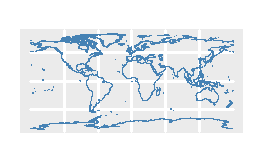

```r
Map1 <- ggplot(data = coastline10)+
  geom_sf(fill = "lightblue", color = "steelblue", linewidth = .2)
print(Map1)
```

The result is a map of the coastline of the world. To set the map to the area we are interested in, first define the minimum and maximum latitude and longitude.

```r
# Define the Latitude and Longitudes of the Map
lon_min_O <- 3.18 # xmin
lon_max_O <- 30.88 # xmax
lat_min_O <- 52.66 # ymin
lat_max_O <- 70.66 # ymax
```

Then use the *coord_sf* function in ggplot to set limits for the map. To remove the grey background and the gridlines use the classic theme in ggplot2, *theme_classic*.

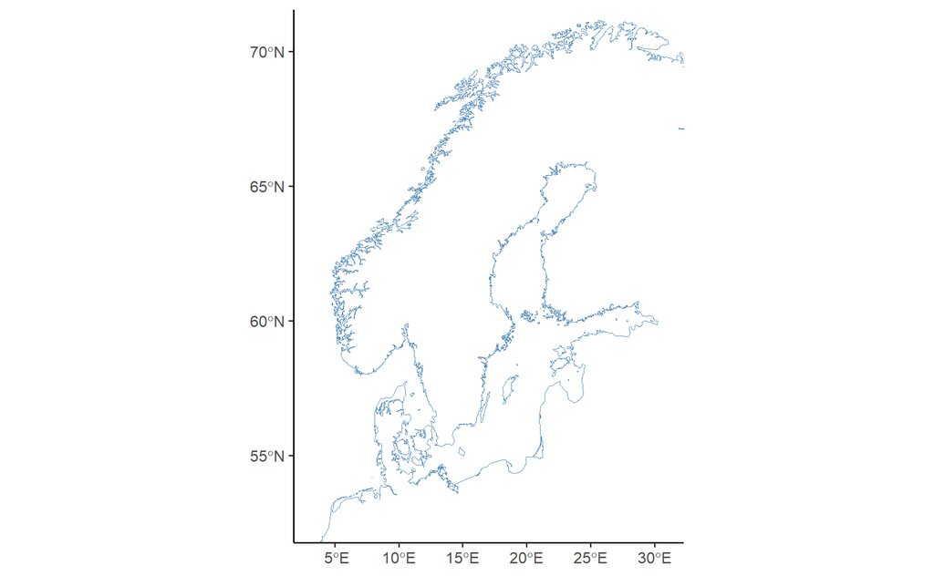

```r
Map2 <- ggplot(data = coastline10) +
  geom_sf(fill = "lightblue", color = "steelblue", linewidth = .2) +
  # Crop the map using the latitude and longitude coordinates above
  coord_sf(xlim = c(lon_min_O, lon_max_O),
           ylim = c(lat_min_O, lat_max_O),
           expand = TRUE) +
  theme_classic()
print(Map2)
```

*Note:* The coastline renders only as a line because the coastline is not a polygon. The fill setting is ignored.

## Save as a GIF file

The result must be printed in order to save the results as a GIF file. The actual size is quite small so the GIF needs to be scaled up. The GIF will have some differences to the plot displayed in the R Plots frame.

```r
scale_factor = 10

ggsave("GIFs/Map2_Ostersjon_Map2_basic_%03d.png",
       plot = last_plot(),
       device = "png",
       scale = scale_factor,
       units="mm",
       limitsize = FALSE,
       dpi=300)
```

```
Saving 178 x 178 mm image
```

## Add Lakes

Download the lakes data from *rnaturalearth*. Set the scale to **10**, the largest scale. Filter to display only top level lakes.

```r
# Download lakes dataset and save as lakes110
lakes10 <- rnaturalearth::ne_download(scale = 10, type = "lakes",
                                       category = "physical") %>%
            dplyr::filter(scalerank < 6)
```

## Convert the coastline into a polygon

First create a rectangle for the bounding box based on the Latitude and Longitude variables above. Then split that rectangle via the coastline10$geometry setting and extract as a Polygon. Split the rectangle parts so [1] is sea and [2] is land.

```r
bb_rect_O <- data.frame(lat = c(lat_min_O, lat_max_O),
                        lon = c(lon_min_O, lon_max_O)) %>%
  st_as_sf(coords = c("lon", "lat"), crs = 4326) %>%
  st_bbox() %>%
  st_as_sfc()

bb_rect_O_split <- bb_rect_O %>%
  lwgeom::st_split(coastline10$geometry) %>%
  sf::st_collection_extract("POLYGON")

sea_O  <- bb_rect_O_split[1]
land_O <- bb_rect_O_split[2]
```

### Create Map

Create a map that sets the sea as light blue, the land is outlined in steel blue and the lad is antique white. **geom_sf(fill) Displays sea as light blue, land outline as steel blue and land as antique white (taken from the panel.background fill). The lakes are filled in light blue.

The code below takes the sea_O polygon, outlines it in steel blue and fills it in light blue.

*ggplot(data = sea_O) + geom_sf(fill = “lightblue”, color = “steelblue”)*  
Adds the lakes filled in light blue. *geom_sf(data=lakes10, fill = “lightblue”)*

The following theme settings hide the tick lines, the longitude and latitude lines and the X and Y titles. Setting he panel.grid.major and minor to element_blank removes the gridlines. The panel border is set to black outline with a line width of .3 in the panel.border settings.  
Setting the panel.background setting to an antique white fill sets anywhere that is not sea to be antique white. *theme(axis.line = element_line(), axis.ticks = element_blank(), # hides the Lat, Long tick lines axis.text.x = element_blank(), # hides the Longitude lines axis.text.y = element_blank(), # hides the Latitude lines axis.title = element_blank(), # hides the X and Y titles panel.grid.major = element_blank(), panel.grid.minor = element_blank(), panel.border = element_rect(colour = “black”, fill=NA, linewidth =.3), panel.background = element_rect(fill = “antiquewhite”))*

```r
Map3 <- ggplot(data = sea_O) +
  geom_sf(fill = "lightblue",
          color = "steelblue") +
  geom_sf(data=lakes10, fill = "lightblue") +
  coord_sf(xlim = c(lon_min_O +1.2, lon_max_O -.8),
           ylim = c(lat_min_O +.8, lat_max_O -.8),
           expand = TRUE) +
  theme(axis.line = element_line(),
        axis.ticks = element_blank(),  # hides the Lat, Long tick lines
        axis.text.x = element_blank(), # hides the Longitude lines
        axis.text.y = element_blank(), # hides the Latitude lines
        axis.title = element_blank(),  # hides the X and Y titles
        panel.grid.major = element_blank(),
        panel.grid.minor = element_blank(),
        panel.border = element_rect(colour = "black", fill=NA, linewidth =.3),
        panel.background = element_rect(fill = "antiquewhite"))
```

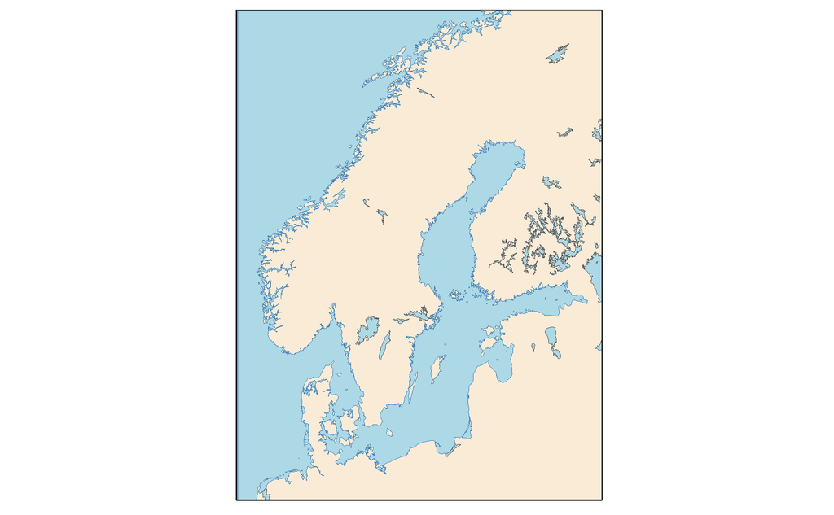

```r
ggsave("GIFs/Map2_Ostersjon_Map3_3%03d.png",
       plot = last_plot(),
       device = "png",
       scale = scale_factor,
       units="mm",
       limitsize = FALSE,
       dpi=300)
```

```
Saving 178 x 178 mm image
```

### Add Town, Sea and Country data

```r
# Read in file containing towns, seas and countries
Map_coordinates_O <- readxl::read_excel("Data/Map2_Balticmap_coordinates_v4.xlsx",
                                             sheet = "Sheet1", range = "A1:F47",
                                             col_types = c("text", "text", "numeric",
                                                           "numeric", "text", "text")) %>%
  # Correct some of the Town names
  # Add a new column "Label" based on Ort.
  # Split some of the town names into 2 lines using \n
  dplyr::mutate(Label = case_when(Ort == "Stettin" ~ "Stettin / Szczecin",
                                  Ort == "Königsberg" ~ "Königsberg / Kaliningrad",
                                  Ort == "Hela" ~ "Hela /\nHel",
                                  Ort == "Danzig / Gdansk" ~ "Danzig /\nGdansk",
                                  Ort == "Stolpmünde / Utska" ~ "Stolpmünde /\nUtska",
                                  TRUE ~ Ort)) %>%
  # Add a new column "Type" which is set to Country if the Ort column and Land column are the same
  # Sea if the Ort column is "Kattegatt", "Östersjön", "Skagerrak", "Nordsjön" and otherwise set to City
  dplyr::mutate(Type = case_when((Ort == Land) ~ "Country",
                                 Ort %in% c("Kattegatt", "Östersjön",
                                            "Skagerrak", "Nordsjön") ~ "Sea",
                                 TRUE ~ "City")) %>%
  # Add a new column "Fontsize" which is set to 7 if Type is Country,
  # 4 if Ort is one of the capital cities and 3 if any other value
  dplyr::mutate(FontSize = case_when(
    Type == "Country" ~ 7,
    Ort %in% c("Köpenhamn","Stockholm","Oslo") ~ 4,
    TRUE ~ 3)) %>%
  # Add a new column "FontFace" which is set to "bold.italic" if Type is Sea,
  # "bold" if Ort is one of the capital cities and "plain" if any other value
  dplyr::mutate(FontFace = case_when((Type == "Sea") ~ "bold.italic",
                                     Ort %in% c("Köpenhamn","Stockholm","Oslo") ~ "bold",
                                     TRUE ~ "plain")) %>%
  # Add a new column "FontColour" which is set to "steelblue" if Type is Sea,
  # and "black" if any other value
  dplyr::mutate(FontColour = case_when((Type == "Sea") ~ "steelblue",
                                       TRUE ~ "black")) %>%
  # Add a new column NudgeX with values for nudging text labels left or right
  dplyr::mutate(NudgeX = case_when(
    Ort %in% c("Skagerrak") ~ .127,# moved right
    Ort %in% c("Kristiansand") ~ -1,
    Ort %in% c("Göteborg") ~ 1, # moved right
    Ort %in% c("Stettin") ~ 1, # moved right
    Ort %in% c("Königsberg") ~ 2, # moved right
    Ort %in% c("Kragerø") ~ -.2, # moved left
    Ort %in% c("Kiel","Lübeck") ~ -.6, # moved left
    Ort %in% c("Tjörn") ~ -.5, # moved left
    Ort %in% c("Åbo") ~ .2, # moved right
    Ort %in% c("Helsingfors") ~ -.3, # moved left
    Ort %in% c("Strömstad") ~ .52, # moved right
    Ort %in% c("Memel / Klaipėda") ~ .9, # moved right
    Ort %in% c("Königsberg") ~ .2, # moved right
    TRUE ~ 0)) %>%
  # Add a new column NudgeY with values for nudging text labels up or down
  dplyr::mutate(NudgeY = case_when(
    Ort %in% c("Oslo","Åbo","Helsingfors","Luleå",
               "Kemi", "Karlstad", "Stockholm") ~ .05, # moved above
    Ort == "Skagerrak" ~ -.04, # moved below
    Ort == "Kattegatt" ~ -.1,
    Ort == "Kragerø" ~ .15,
    Ort %in% c("Strömstad") ~ .2, # moved above
    Ort %in% c("Hamburg", "Wismar") ~ -.1, # moved below
    TRUE ~ 0))
```

```r
Labels_O <- Map_coordinates_O %>%
  sf::st_as_sf(coords = c("Long", "Lat"), crs = 4326, agr = "constant")

Points_O <- dplyr::filter(Map_coordinates_O, !Mark == "area") %>%
  sf::st_as_sf(coords = c("Long", "Lat"), crs = 4326, agr = "constant")
```

```r
# Displays sea as light blue and points as dark red
plotcoast <- ggplot(data = sea_O) +
  geom_sf(fill = "lightblue",
          color = "steelblue") +
  geom_sf(data=lakes10, fill = "lightblue") +
  geom_sf(data = Points_O, size = 2, shape = 21, fill = "darkred") +
  geom_sf_text(data = Labels_O, aes(label = Label, lineheight = .85),
               size = Labels_O$FontSize) +
  coord_sf(xlim = c(lon_min_O +1.2, lon_max_O -.8),
           ylim = c(lat_min_O +.8, lat_max_O -.8),
           expand = TRUE) +
  theme(axis.line = element_line(),
        axis.ticks = element_blank(),  # hides the Lat, Long tick lines
        axis.text.x = element_blank(), # hides the Longitude lines
        axis.text.y = element_blank(), # hides the Latitude lines
        axis.title = element_blank(),  # hides the X and Y titles
        panel.grid.major = element_blank(),
        panel.grid.minor = element_blank(),
        panel.border = element_rect(colour = "black", fill=NA, linewidth =.3),
        panel.background = element_rect(fill = "antiquewhite"))
```

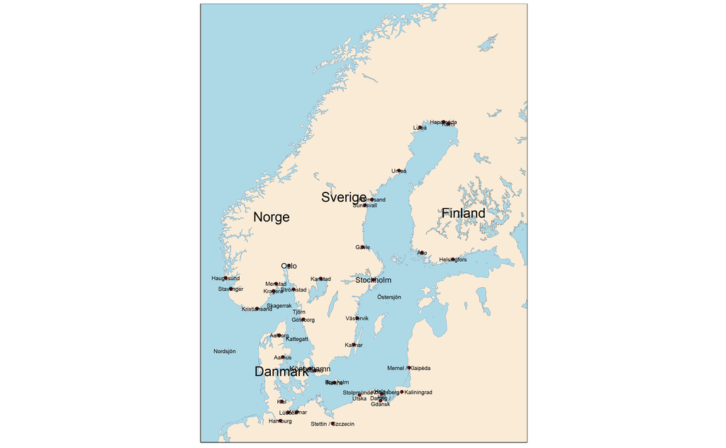

```r
ggsave("GIFs/Map2_Ostersjon_coast_1_%03d.png",
       plot = last_plot(),
       device = "png",
       scale = scale_factor,
       units="mm",
       limitsize = FALSE,
       dpi=300)
```

```
Saving 178 x 178 mm image
```

### Fix overlapping labels

Create a plot using *ggrepel* to ensure the text labels do not overlap. Set the ggrepel.max.overlaps to infinity because there are many text labels.

```r
options(ggrepel.max.overlaps = Inf)
```

```r
plotcoastLabels <- ggplot(data = sea_O) +
  geom_sf(fill = "lightblue",
          color = "steelblue") +
  geom_sf(data=lakes10, fill = "lightblue") +
  geom_sf(data = Points_O, size = 2, shape = 21, fill = "darkred") +
  geom_text_repel(data = Map_coordinates_O,
                  aes(label = Label,
                      x = Long, y = Lat,
                      lineheight = .85),
                  size = Map_coordinates_O$FontSize,
                  fontface = Map_coordinates_O$FontFace,
                  colour = Map_coordinates_O$FontColour,
                  nudge_x = Map_coordinates_O$NudgeX,
                  nudge_y = Map_coordinates_O$NudgeY) +
  coord_sf(xlim = c(lon_min_O +1.2, lon_max_O -.8),
           ylim = c(lat_min_O +.8, lat_max_O -.8),
           expand = TRUE) +
  theme(axis.line = element_line(),
        axis.ticks = element_blank(),  # hides the Lat, Long tick lines
        axis.text.x = element_blank(), # hides the Longitude lines
        axis.text.y = element_blank(), # hides the Latitde lines
        axis.title = element_blank(),  # hides the X and Y titles
        panel.grid.major = element_blank(),
        panel.grid.minor = element_blank(),
        panel.border = element_rect(colour = "black", fill=NA, linewidth =.3),
        panel.background = element_rect(fill = "antiquewhite"))
```

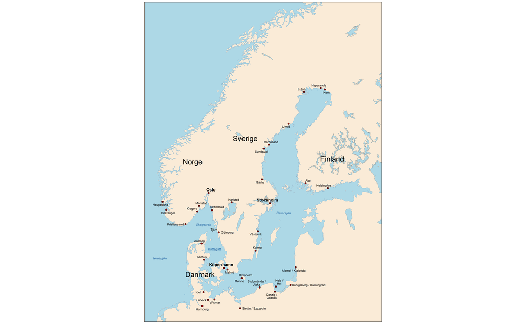

```r
print(plotcoastLabels)
```

```r
# Save as GIF file
ggsave("GIFs/Map2_Ostersjon_coast_withLabel_1_%03d.png",
       plot = last_plot(),
       device = "png",
       scale = scale_factor,
       units="mm",
       limitsize = FALSE,
       dpi=300)
```

```
Saving 178 x 178 mm image
```